# Presentation of heart data project

11_05_2021

## Introduction

Data was pulled on 27. April 2021 and is available at: https://archive.ics.uci.edu/ml/datasets/Heart+Disease?fbclid=IwAR3SbR6Eo3ow8dYal4mTv321XOUAUg8yw5g_WY-eDz9hUQS_0jJ0-qTR9v8

Created in 1988 by:

- Hungarian Institute of Cardiology. Budapest: Andras Janosi, M.D.
- University Hospital, Zurich, Switzerland: William Steinbrunn, M.D.
- University Hospital, Basel, Switzerland: Matthias Pfisterer, M.D.
- V.A. Medical Center, Long Beach and Cleveland Clinic Foundation: Robert Detrano, M.D., Ph.D.
- Contains information of heart patients from 4 locations: Cleveland, Hungary, Switzerland and Long Beach.

Goal of study

- Perform visual analysis of data distribution
- Try to predict if patients have heart disease or not according to features in the dataset (PCA, K-means, Binomial regression)

## Materials and methods: Data processing

`-` Data processing, modeling and creation of presentation was performed in Rstudio Cloud.

`-` Way of coding follows O’Reillys R for Data Science by Wickham and Grolemund

`-` Data wrangling was achieved through *piping* (`%>%`)

`-` Whole project exists at github at: https://github.com/rforbiodatascience21/2021_group01_final_project

## Project outline

- Loading and cleaning data
  - Add location variable
  - Join data sets
- Augmentation of data
  - Create categorical variables
- Analysis and Visualisations
  - Distribution of presence of heart disease across physiological variables.
- Unsupervised analysis
  - PCA
  - K-means clustering
- Supervised classification model
  - Binomial regression

## Data wrangling and cleaning

### Data Import

- Modified version of data sets was used
- Identifiers for the variables was not released for raw data
- 14/76 attributes was used
- The Cleveland database is the only one that has been used by ML researchers to this date
- Example of snippet raw data collected from Cleveland

```
## # A tibble: 4 x 9
##   `63.0` `1.0` `1.0_1` `145.0` `233.0` `1.0_2` `2.0` `150.0` `0.0`
##    <dbl> <dbl>   <dbl>   <dbl>   <dbl>   <dbl> <dbl>   <dbl> <dbl>
## 1     67     1       4     160     286       0     2     108     1
## 2     67     1       4     120     229       0     2     129     1
## 3     37     1       3     130     250       0     0     187     0
## 4     41     0       2     130     204       0     2     172     0
```

## All included variables

| Age | Sex | Chest_pain_type | Resting_blood_pressure | Serum_cholestoral |
| --- | --- | --- | --- | --- |
| 63 | 1 | 1 | 145 | 233 |
| 67 | 1 | 4 | 160 | 286 |
| 67 | 1 | 4 | 120 | 229 |

| Fasting_blood_sugar | Resting_electrocardiographic | Maximum_heart_rate_achieved | Exercise_induced_angina | ST_depression_induced_by_exercise |
| --- | --- | --- | --- | --- |
| 1 | 2 | 150 | 0 | 2.3 |
| 0 | 2 | 108 | 1 | 1.5 |
| 0 | 2 | 129 | 1 | 2.6 |

| The_slope_of_the_peak_exercise_ST_segment | Number_of_major_vessels_colored_by_flourosopy | Thal | diagnosis_of_heart_disease |
| --- | --- | --- | --- |
| 3 | 0 | 6 | 0 |
| 2 | 3 | 3 | 2 |
| 2 | 2 | 7 | 1 |

## Data Cleaning

- Joined together the 4 data frames - Handling of missing values

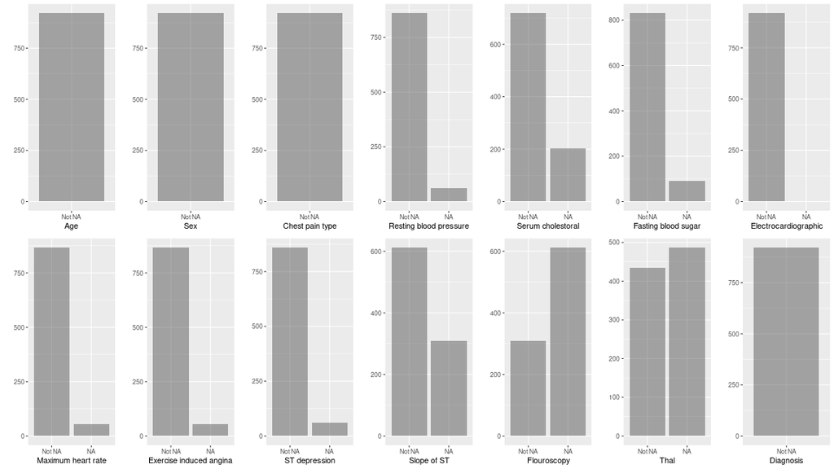

## Tidying and wrangling data

Data was augmented by creating new more insightful columns

- Created categorical age groups for patients, location, diagnosis of disease, sex, chest pain type, fasting blood sugar, resting electrocardiographic, exercise induced angina, slope of ST and thal

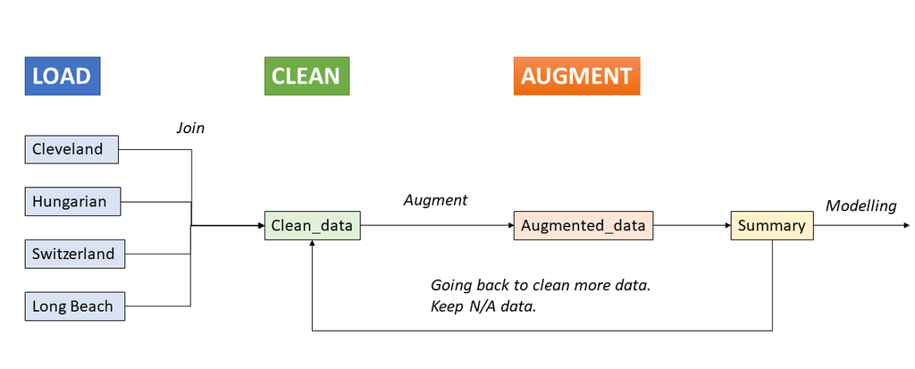

## Descriptive data analysis and visualisations

| type | mean w. sd | min | max |
| --- | --- | --- | --- |
| Age | 53.51 (±9.42) | 28.0 | 77.0 |
| Maximum_heart_rate_achieved | 137.55 (±25.93) | 60.0 | 202.0 |
| Resting_blood_pressure | 132.29 (±18.54) | 80.0 | 200.0 |
| Serum_cholestoral | 246.83 (±58.53) | 85.0 | 603.0 |
| ST_depression_induced_by_exercise | 0.88 (±1.09) | -2.6 | 6.2 |

## Descriptive data analysis and visualisations

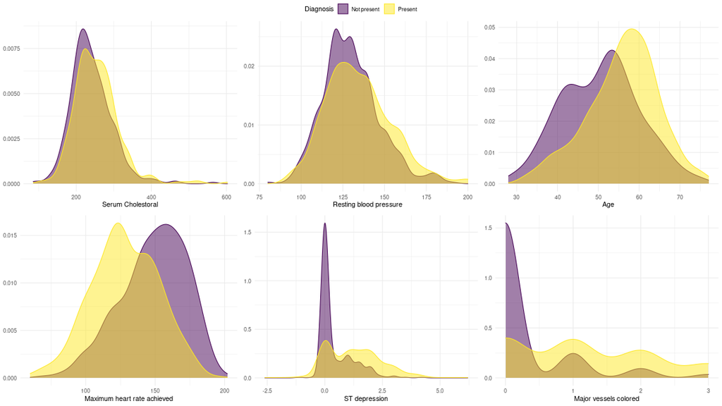

## Descriptive data analysis and visualisations

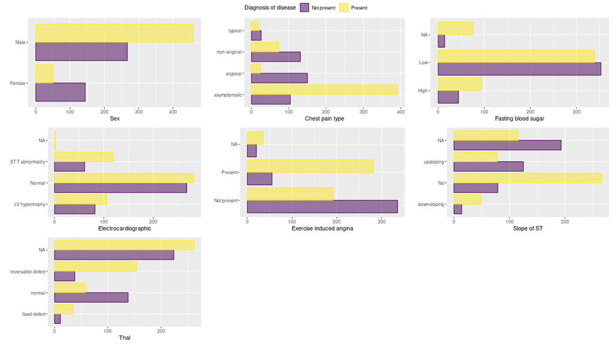

## Unsupervised learning: Results from PCA

- Data wrangling and handling of NAs
- Regions in which the majority of the pool of observations show consistency in presence/absence of disease
- The first three PCs account for ~70% of the total variance
- Indicating that we should be able to separate observations with presence of disease from absence of disease

## Unsupervised learning: Results from PCA

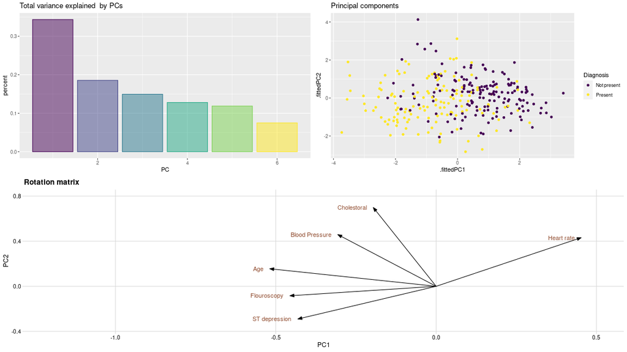

## Unsupervised learning: Kmeans Cluster

- Handling of NA and selection of data
- Performed on PCA data for K = 2

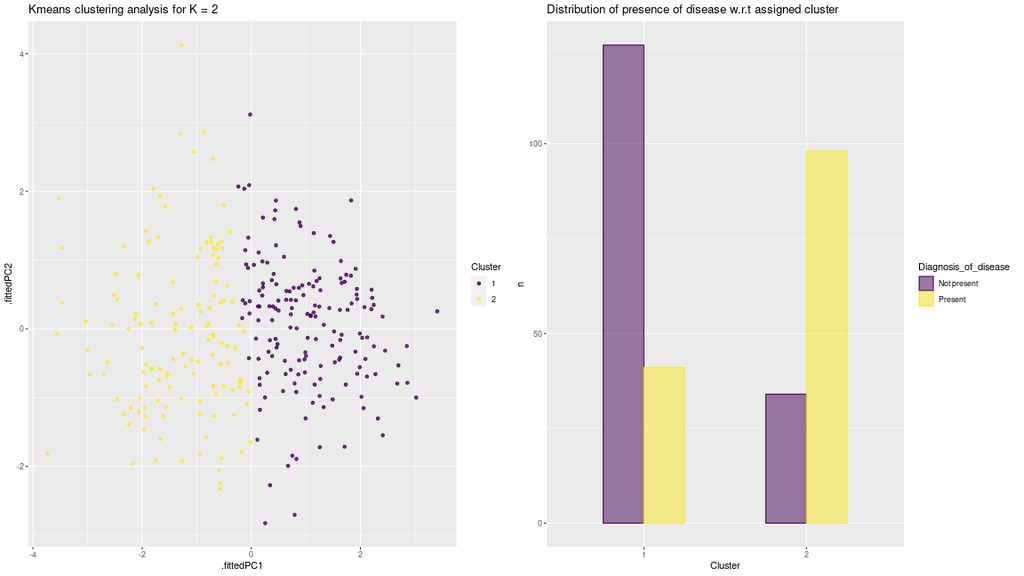

## Unsupervised learning: Kmeans Cluster

- Classifies ~ 75% is correctly “classified”

| True Positive | False Positive | False Negative | True Negative |
| --- | --- | --- | --- |
| 98 | 34 | 41 | 126 |

| accuracy | Precision | Recall | F_score |
| --- | --- | --- | --- |
| 0.749 | 0.742 | 0.705 | 0.723 |

## Supervised learning: Prediction model based on presence of heart disease

- Two binomial regression was created:
  - The first binomial Regression model predicts the odds of being diagnosed with a heart disease, given the participants age
  - The first binomial Regression model predicts the odds of being diagnosed with a heart disease, given the participants age, gender and type of chest pain

    | Model_formular | True Positive | False Positive | False Negative | True Negative |
    | --- | --- | --- | --- | --- |
    | Diagnosis_of_disease_No ~ Age | 123 | 66 | 29 | 58 |
    | Diagnosis_of_disease_No ~ Age+Sex+Chest_pain_type | 134 | 35 | 18 | 89 |

## Confusion matrix

- Based on the result of from the confusion matrix, it intuitively seems that the second is the better predictor model
- This is further illustrated by the result of the in the second table:
- As can be seen in the table the accuracy, precision, recall and F score is higher for the second model, which means the second model is the better model

  | Model_formular | accuracy | Precision | Recall | F_score |
  | --- | --- | --- | --- | --- |
  | Diagnosis_of_disease_No ~ Age | 0.656 | 0.651 | 0.809 | 0.721 |
  | Diagnosis_of_disease_No ~ Age+Sex+Chest_pain_type | 0.808 | 0.793 | 0.882 | 0.835 |

## Discussion

### Considerations concerning the data used

Use of all 4 databases vs. use of Cleveland_data only

Missing information as a result of removing rows containing NA

Old data sets might have some medical measurements that could be irrelevant and outdated for prediction today